# Prep 2: Population analysis

Conducting the analysis with stateELP

Guide home | Previous: Prep 1: Policy documentation | Next: Prep 3: Program implementation

**Simulated data**

Every output on this page comes from the package’s simulated data. It shows what this step produces and how to read it. It says nothing about any real state: every gap, ratio and rate here comes from how the data were generated.

```r
library(stateELP)
```

## What this step answers

Prep 2 describes the English learner (EL) population before any check asks how well the exit rule works. An EL is a student identified as needing English language support. ELP is English language proficiency, as measured by the state’s ELP test. The step answers three questions:

- **How many ELs are there, and is the number stable over time?**
- **Where are they?** Which grades and districts, entering at what grade and ELP level, with what profile.
- **What can the later stages safely analyze?** Which cohorts and subgroups are large and stable enough, and where would pooling all ELs together hide more than it shows?

Every later stage is read against this one. A grade-level result in Check 3 may reflect unusual entry timing, a thin count, or many long-term ELs rather than the exit threshold. Prep 2 is where you find out.

## Sample

**The full statewide EL population, across every year the data cover. Not a single cohort.**

- **Current ELs** in every year of the panel (the span of school years in the delivery).
- **Former ELs**, students who have exited EL status, where the delivery carries them. Simulated former ELs leave the data after their fourth monitoring year, so “former” means former within the monitoring window.
- **Never-EL students** only as the enrollment denominator for the EL share, and only weighted.

Later stages use different samples: Checks 1 and 2 follow one entry cohort, and Checks 3 and 4 use a cross-section by grade and year. The results object carries this stage’s sample statement in `$meta$sample`. The process calls for at least five years; with fewer, `$meta$short_panel` is `TRUE` and the stage report flags trends as provisional.

## Status in the package

**Built.** `run_prep2()` fills every slot in the stage’s instruction file, and the stage report renders from it. Before you rely on it, know that:

- Five slots go beyond the instruction file’s list: `$entry_sources`, `$entry_by_year`, `$entry_cohorts`, `$time_in_status` and `$blocked_groups`. They, and several method choices, are marked `[PROPOSED — CONFIRM]`: dating entry from delivered fields, the monitoring view, reading a multi-criterion rule as “all criteria must pass,” and leaving true zeros unsuppressed.
- The criteria crosswalk has run on a Type 2 variant of the simulated spec and a small ELPA21-shaped test fixture, not yet on a real multi-criterion state.
- `$profile$HERITAGE` is always `NULL`: no delivered field carries heritage-language status yet.

## Before you start

### Data

Prep 2 takes an `el_data` bundle from `as_el_data()` built from two tables. The **roster** has one row per student per school year (a *student-year*) and is the only table students are counted from. The **ELP base table** has one row per student, year and score component. The academic table is not used.

The roster must carry `STUDENT_ID`, `YEAR`, `GRADE` and `EL_STATUS` (`current`, `former` or `never`); if one is missing, `as_el_data()` stops and names it, and `run_prep2()` checks again. Everything else is optional. Each absence turns off only the view that needs it, and that slot comes back `NULL` rather than failing:

| Input | Unlocks | Without it |
| --- | --- | --- |
| Never-EL rows, with `SAMPLE_WEIGHT` | `$el_share` | `NULL`. With never-EL rows but no `SAMPLE_WEIGHT`, every row counts once |
| `DISTRICT_ID` | `$by_district`, `$district_bins` | Both `NULL` |
| `policy$district_size_bands` in the spec | `$district_bins` | `NULL`; districts are still ranked |
| An entry field: `LEP_PROGRAM_START_DATE`, `COHORT_START_YEAR`, `YEAR_IN_STATUS` or `ENTRY_GRADE` | Entry dates for students already EL when the panel opens | Their entry is *unknown*: they leave the entry views, and the long-term share becomes a range |
| Annual-form rows in the base table | Initial ELP bands; the coverage split | Entrants with no annual score form their own group |
| `policy$timelines$lt_el_years` in the spec | `$time_in_status` and its profile table | `NULL` |
| Former rows plus `EL_MONITOR_YEAR` or `EL_STATUS_DETAIL` | `$monitoring` | `NULL` |
| Profile columns (`HOME_LANGUAGE`, `SERVICE_MODEL`, `IEP`, `SPED_CLASSIFICATION`, `GENDER`, `FRL`, `FRL_DETAIL`, `ELP_FORM`, `NEWCOMER_FLAG`, `SIFE_FLAG`, `IMMIGRANT_STATUS`, `MIGRANT_STATUS`) | One profile table each | That table is absent |
| An exit rule of Type 2–6 with two or more ELP criteria in one pathway | `$criteria_crosswalk`, `$contested_zone`, `$blocked_groups` | All three `NULL` |

### Spec

Check these spec fields before you run anything:

```r
spec <- read_el_spec("00_SIM_EL_Spec")

spec$policy$suppression$min_cell                  # smallest reportable cell
```

```
[1] 10
```

```r
str(spec$policy$district_size_bands[c("breaks", "labels")])
```

```
List of 2
 $ breaks: num [1:4] 0 100 1000 Inf
 $ labels: chr [1:3] "<100" "101-999" "1,000+"
```

```r
str(spec$policy$timelines[c("max_years_to_exit", "lt_el_years",
                            "initial_elp_source")])
```

```
List of 3
 $ max_years_to_exit : int 6
 $ lt_el_years       : int 6
 $ initial_elp_source: chr "first_annual"
```

```r
spec$data$entry_date_rule                         # how start dates map to years
```

```
[1] "calendar_year"
```

```r
spec_exit_types(spec)                             # exit-rule Type(s)
```

```
[1] 1
```

- **`min_cell`**: counts from 1 to `min_cell - 1` are hidden (`NA` in the results, a dash in the tables); the row stays.
- **`max_years_to_exit`**: which cohorts are followed long enough to see the full exit window.
- **`lt_el_years`**: a long-term EL (LTEL) is a current EL in this year of status or later.
- **`initial_elp_source`**: `"first_annual"` takes the first annual score at or after entry as the initial level; any other value, or none, uses the entry year’s score only. (Checks 1 and 2 accept only the first annual score, so set `"first_annual"` explicitly if the stages are to agree.)
- **`entry_date_rule`**: by default a start date from July on belongs to the next spring’s school year. The simulated data stamp the spring year itself, hence `"calendar_year"`.
- **The exit-rule Type** gates the last section of this page. The simulated spec is Type 1: a single overall score.

## Run it

Build the bundle once, then run the stage. On the full simulated panel each call takes a little while.

```r
bundle <- as_el_data(el_long_sim, roster = el_roster_sim, spec = spec)
res <- run_prep2(bundle, spec)
```

With your own data the calls are the same:

```r
spec   <- read_el_spec("specs/XX_EL_Spec.R")
bundle <- as_el_data(elp_base, roster = roster, spec = spec)
res    <- run_prep2(bundle, spec)
```

Then check what came back:

```r
cat(res$meta$sample)
```

```
Full statewide EL population: every student identified as an English learner (current and former, within the monitoring window), observed across 11 years (2015–2025). Not a single cohort. Never-EL students enter only as the enrollment denominator.
```

```r
names(res)
```

```
 [1] "counts_by_year"       "el_share"             "by_grade_span"
 [4] "by_grade"             "by_district"          "district_bins"
 [7] "entry_sources"        "entry_grade"          "entry_by_year"
[10] "entry_cohorts"        "time_in_status"       "initial_elp"
[13] "profile"              "monitoring"           "analytic_sample_memo"
[16] "criteria_crosswalk"   "blocked_groups"       "contested_zone"
[19] "meta"
```

```r
names(res)[vapply(res, is.null, logical(1))]   # slots that came back NULL
```

```
[1] "criteria_crosswalk" "blocked_groups"     "contested_zone"
```

Here only the three Type-gated slots are `NULL`. Every other slot is aggregate (tables, the memo text and `$meta`). `$blocked_groups`, when a multi-criterion rule fills it, has one row per student-year. Never print or share it.

## What you get

Each view below uses the display helper the stage report uses: a `plot_*()` function per figure and an `ft_prep2_*()` function per table. Each takes the computed slot and recomputes nothing.

### Coverage: who is counted

```r
ft_prep2_coverage(res)
```

| Year | Current ELs | Annual Overall Composite | Alternate form | No annual score | Former ELs |
| --- | --- | --- | --- | --- | --- |
| 2015 | 16,176 | 15,216 | 66 | 894 | 3,281 |
| 2016 | 18,492 | 17,385 | 80 | 1,027 | 4,736 |
| 2017 | 20,176 | 18,894 | 101 | 1,181 | 6,410 |
| 2018 | 21,537 | 20,126 | 106 | 1,305 | 7,893 |
| 2019 | 22,510 | 21,014 | 119 | 1,377 | 9,327 |
| 2020 | 23,334 | 20,860 | 130 | 2,344 | 10,493 |
| 2021 | 24,058 | 18,443 | 139 | 5,476 | 11,131 |
| 2022 | 24,915 | 23,195 | 144 | 1,576 | 11,226 |
| 2023 | 24,762 | 22,938 | 156 | 1,668 | 11,995 |
| 2024 | 24,830 | 22,963 | 161 | 1,706 | 12,341 |
| 2025 | 24,938 | 23,037 | 169 | 1,732 | 12,515 |

This comes from `$counts_by_year`. Each year’s current ELs (`N_CURRENT`) split into three groups that sum to it before suppression: an annual-form result on the Overall Composite, the ELP score the simulated exit rule uses (`N_ANNUAL_HEADLINE`); the alternate form (`N_ALTERNATE`); or no result that year (`N_NO_HEADLINE`). The table also shows former ELs (`N_FORMER`). The slot carries a weighted-only never-EL count, `N_NEVER_WEIGHTED`, which the table leaves out on purpose: never-ELs matter here only as the enrollment denominator.

In 2021, 5,476 of 24,058 current ELs have no annual score: the simulation builds in a testing-participation dip that year. The current-EL count does not dip. That is why the roster is the counting frame: counting from scores would turn an untested year into apparent attrition.

### EL counts and share of enrollment

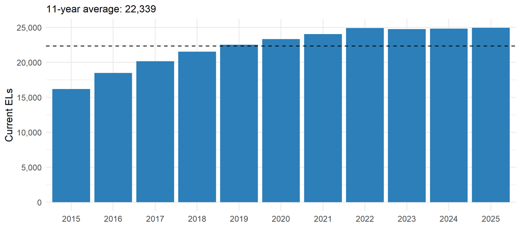

```r
plot_counts_by_year(res$counts_by_year)
```

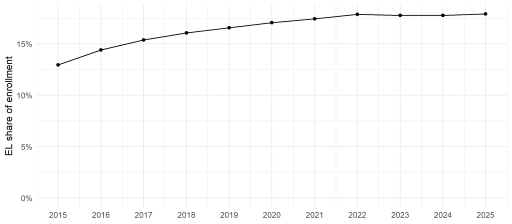

```r
plot_el_share(res$el_share)
```

```r
ft_prep2_el_share(res)
```

| Year | Enrollment (weighted) | Current ELs | EL share |
| --- | --- | --- | --- |
| 2015 | 124,867 | 16,176 | 13.0% |
| 2016 | 128,288 | 18,492 | 14.4% |
| 2017 | 131,096 | 20,176 | 15.4% |
| 2018 | 134,070 | 21,537 | 16.1% |
| 2019 | 135,827 | 22,510 | 16.6% |
| 2020 | 136,787 | 23,334 | 17.1% |
| 2021 | 137,909 | 24,058 | 17.4% |
| 2022 | 139,481 | 24,915 | 17.9% |
| 2023 | 139,407 | 24,762 | 17.8% |
| 2024 | 139,691 | 24,830 | 17.8% |
| 2025 | 139,293 | 24,938 | 17.9% |

The bars count current ELs by year; the dashed line is the panel average. The share (`$el_share`: `N_ENROLLMENT_WEIGHTED`, `N_EL_WEIGHTED`, `PCT_EL`) is **weighted by `SAMPLE_WEIGHT`**. The simulated never-EL rows are a sample, each with a weight of 10, so an unweighted share would read several times too high. Shares across the whole state are weighted; statistics within the EL population are not.

### Grades

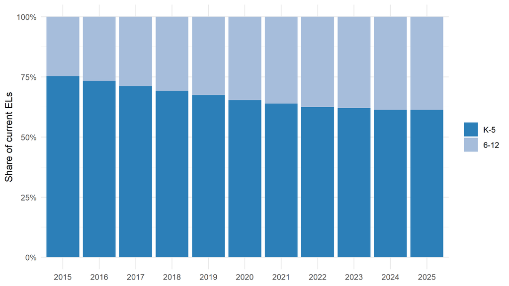

```r
plot_by_grade_span(res$by_grade_span)
```

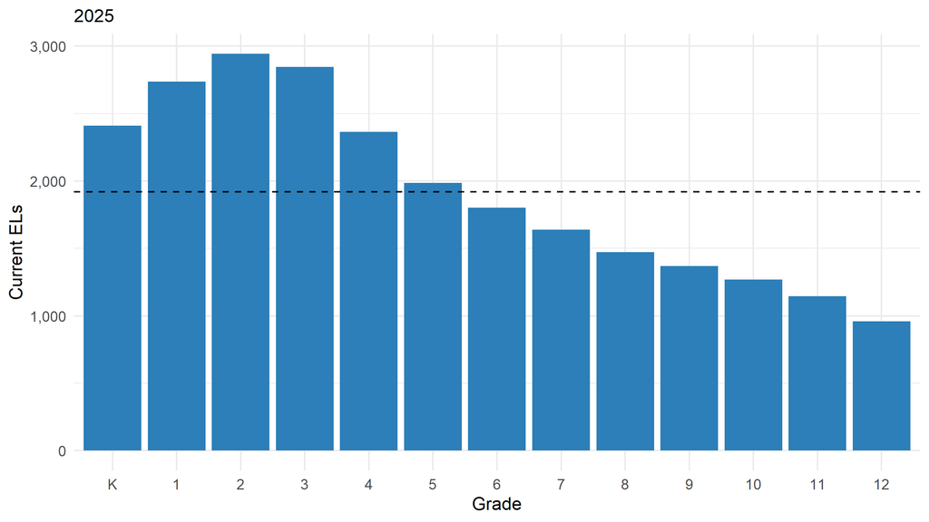

```r
plot_by_grade(res$by_grade)
```

```r
ft_prep2_grade_shares(res)
```

| Grade | 2015 | 2016 | 2017 | 2018 | 2019 | 2020 | 2021 | 2022 | 2023 | 2024 | 2025 |
| --- | --- | --- | --- | --- | --- | --- | --- | --- | --- | --- | --- |
| K | 14.7% | 12.8% | 11.9% | 11.2% | 10.5% | 10.3% | 9.8% | 9.5% | 9.7% | 9.7% | 9.7% |
| 1 | 15.7% | 14.5% | 13.2% | 12.8% | 12.2% | 11.5% | 11.2% | 10.8% | 11.0% | 10.8% | 11.0% |
| 2 | 15.3% | 14.9% | 14.2% | 13.4% | 13.1% | 12.7% | 12.1% | 11.8% | 11.7% | 12.1% | 11.8% |
| 3 | 12.5% | 12.9% | 13.2% | 12.6% | 12.2% | 12.1% | 11.8% | 11.4% | 11.2% | 11.0% | 11.4% |
| 4 | 9.7% | 10.3% | 10.4% | 11.0% | 10.4% | 10.4% | 10.5% | 10.3% | 9.9% | 9.7% | 9.5% |
| 5 | 7.4% | 7.9% | 8.3% | 8.2% | 8.9% | 8.3% | 8.5% | 8.6% | 8.5% | 8.0% | 8.0% |
| 6 | 6.4% | 6.6% | 7.1% | 7.3% | 7.3% | 7.9% | 7.4% | 7.7% | 7.3% | 7.5% | 7.2% |
| 7 | 4.3% | 5.5% | 5.5% | 6.0% | 6.3% | 6.4% | 6.7% | 6.4% | 6.6% | 6.3% | 6.6% |
| 8 | 4.0% | 4.1% | 5.0% | 5.0% | 5.5% | 5.7% | 5.9% | 6.2% | 5.9% | 6.0% | 5.9% |
| 9 | 3.4% | 3.7% | 3.9% | 4.5% | 4.5% | 5.0% | 5.3% | 5.5% | 5.6% | 5.6% | 5.5% |
| 10 | 2.9% | 2.9% | 3.1% | 3.3% | 3.9% | 4.0% | 4.4% | 4.8% | 5.0% | 5.1% | 5.1% |
| 11 | 2.2% | 2.4% | 2.4% | 2.7% | 2.9% | 3.4% | 3.5% | 4.0% | 4.3% | 4.5% | 4.6% |
| 12 | 1.4% | 1.5% | 1.8% | 1.9% | 2.1% | 2.2% | 2.8% | 2.9% | 3.3% | 3.7% | 3.8% |

`$by_grade_span` splits current ELs into K–5 and 6–12 each year (100% stacked). `$by_grade` has one row per year and grade, K–12 (`YEAR`, `GRADE`, `N`, `PCT`, `SUPPRESSED`); an empty grade is a zero row, not a gap. The bar chart shows the latest year, with the average across grades dashed. In the share table, read down a column for concentration and across a row for drift.

### Districts

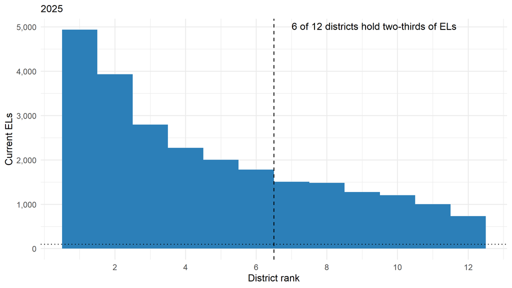

```r
plot_by_district(res$by_district)
```

```r
ft_prep2_district_bins(res)
```

| District EL count | Districts | Current ELs | Share of ELs |
| --- | --- | --- | --- |
| <100 | 0 | 0 | 0.0% |
| 101-999 | 1 | 734 | 2.9% |
| 1,000+ | 11 | 24,204 | 97.1% |

```r
ft_prep2_districts(res)
```

| Rank | District | Current ELs | Cumulative share |
| --- | --- | --- | --- |
| 1 | D01 | 4,937 | 19.8% |
| 2 | D02 | 3,933 | 35.6% |
| 3 | D03 | 2,797 | 46.8% |
| 4 | D04 | 2,271 | 55.9% |
| 5 | D05 | 2,005 | 63.9% |
| 6 | D06 | 1,782 | 71.1% |

`$by_district` ranks districts by current-EL count in the latest year (`RANK`, `DISTRICT_ID`, `N`, `PCT_CUM`, `TWO_THIRDS`, `SIZE_BAND`). The chart shows rank, not name. The dashed line marks the rank where the cumulative share first reaches two-thirds. The dotted line is the small-district threshold: the upper edge of the smallest spec band (100 here). `$district_bins` counts districts and ELs per band. The last table lists the districts that together hold two-thirds of ELs, which is where a threshold change lands hardest.

The simulated state has only 12 districts, with 0 below the small-district line. A real state will often show a long tail.

### Entry and candidate cohorts

Prep 2 dates each student’s entry into EL status from the first of these fields that is delivered and filled for that student, in this order: `LEP_PROGRAM_START_DATE`, `COHORT_START_YEAR`, `YEAR_IN_STATUS`, `ENTRY_GRADE` (reorder with `spec$data$entry_sources`). A delivered year later than the student’s first observed `current` year is pulled back to it. Without any of these fields, the panel can date only students who first turn `current` after it opens, plus K students in its first year. Anyone else already EL when the panel opens has an *unknown* entry.

```r
ft_prep2_entry_sources(res)
```

| Entry year dated from | Students | Share |
| --- | --- | --- |
| LEP_PROGRAM_START_DATE | 59,816 | 100.0% |

```r
cat(paste0("- ", res$meta$notes$entry), sep = "\n")
```

- On the first observed current year of in-panel entrants, `YEAR_IN_STATUS` is 1 for 100.0% of them, so it is read as counting the current year (first year = 1) [DERIVED - VERIFY].
- Delivered entry fields cover 100.0% of ever-current students. Where the panel also observes the entry (43,640 students first current after 2015), the delivered year matches the first current year for 100.0%; 0 delivered years fell after an observed current year and were pulled back to it.
- Left-truncation recomputed here agrees with the delivered `LEFT_TRUNCATED` flag for 100.0% of students.

Read these notes (`$meta$notes$entry`) every run. They say whether `YEAR_IN_STATUS` codes a first year as 1 or 0 (detected, `[DERIVED — VERIFY]`) and how often delivered entry years agree with the panel. If agreement is low, check `entry_date_rule` and `spec$data$years_in_status_first_value`.

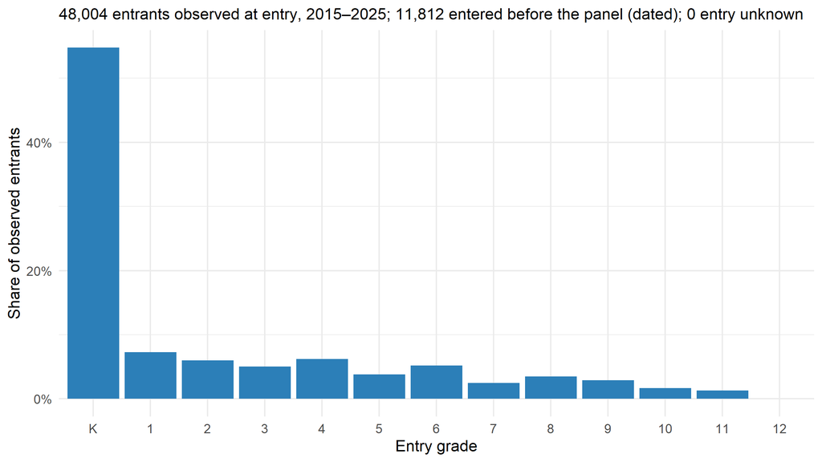

```r
plot_entry_grade(res$entry_grade)
```

```r
ft_prep2_entry_cohorts(res)
```

| Entry year | Entrants | Years observed | Covers full exit window |
| --- | --- | --- | --- |
| 2015 | 2,373 | 11 | yes |
| 2016 | 2,360 | 10 | yes |
| 2017 | 2,411 | 9 | yes |
| 2018 | 2,403 | 8 | yes |
| 2019 | 2,374 | 7 | yes |
| 2020 | 2,408 | 6 | no |
| 2021 | 2,350 | 5 | no |
| 2022 | 2,370 | 4 | no |
| 2023 | 2,406 | 3 | no |
| 2024 | 2,410 | 2 | no |
| 2025 | 2,410 | 1 | no |

`$entry_grade` counts entrants by grade at entry, among students whose entry falls inside the panel. `$entry_by_year` crosses entry year with entry grade (`ft_prep2_entry_by_year(res)`).

`$entry_cohorts` lists every kindergarten entry cohort. A *cohort* is the students who entered EL status in the same grade and year. `FOLLOWUP_YEARS` is how many years the panel observes it. `FULL_WINDOW` says whether that covers the state’s maximum timeline plus the year needed to observe an exit in its last year. Shorter cohorts are usable but *censored*: their later years fall outside the data, so exits there are not yet observed. Membership comes from the same shared function Check 1 uses, so the two cannot disagree about who is in a cohort.

### Time in status: new and long-term ELs

```r
ft_prep2_time_by_year(res)
```

| Year | Current ELs | First year in status | Long-term EL, at least | Long-term EL, at most | Entry unknown |
| --- | --- | --- | --- | --- | --- |
| 2015 | 16,176 | 27.0% | 6.2% | 6.2% | 0.0% |
| 2016 | 18,492 | 23.6% | 8.3% | 8.3% | 0.0% |
| 2017 | 20,176 | 21.6% | 10.7% | 10.7% | 0.0% |
| 2018 | 21,537 | 20.3% | 13.5% | 13.5% | 0.0% |
| 2019 | 22,510 | 19.4% | 16.6% | 16.6% | 0.0% |
| 2020 | 23,334 | 18.7% | 19.3% | 19.3% | 0.0% |
| 2021 | 24,058 | 18.1% | 21.6% | 21.6% | 0.0% |
| 2022 | 24,915 | 17.5% | 23.5% | 23.5% | 0.0% |
| 2023 | 24,762 | 17.6% | 24.3% | 24.3% | 0.0% |
| 2024 | 24,830 | 17.6% | 24.6% | 24.6% | 0.0% |
| 2025 | 24,938 | 17.5% | 25.0% | 25.0% | 0.0% |

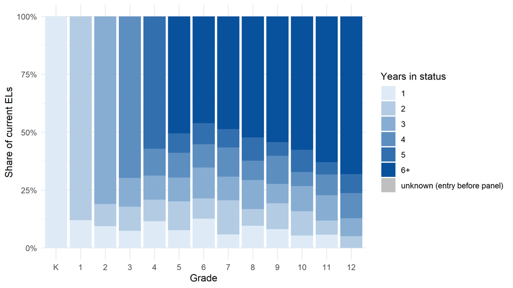

```r
plot_time_in_status(res$time_in_status)
```

```r
ft_prep2_time_by_grade(res)
```

| Grade | Current ELs | First year in status | Long-term EL | Entry unknown |
| --- | --- | --- | --- | --- |
| K | 2,410 | 100.0% | 0.0% | 0.0% |
| 1 | 2,738 | 12.0% | 0.0% | 0.0% |
| 2 | 2,942 | 9.4% | 0.0% | 0.0% |
| 3 | 2,846 | 7.4% | 0.0% | 0.0% |
| 4 | 2,365 | 11.5% | 0.0% | 0.0% |
| 5 | 1,986 | 7.7% | 50.5% | 0.0% |
| 6 | 1,801 | 12.7% | 46.1% | 0.0% |
| 7 | 1,638 | 5.9% | 48.7% | 0.0% |
| 8 | 1,471 | 9.7% | 52.3% | 0.0% |
| 9 | 1,368 | 8.1% | 54.2% | 0.0% |
| 10 | 1,269 | 5.4% | 57.6% | 0.0% |
| 11 | 1,146 | 5.8% | 62.9% | 0.0% |
| 12 | 958 | 0.0% | 68.1% | 0.0% |

Time in status counts from the entry year dated above. `$time_in_status` holds `by_year` (`N`, `PCT_NEW`, `PCT_LT_MIN`, `PCT_LT_MAX`, `PCT_UNKNOWN`), `by_grade` (the same by grade, for the latest year) and a years-in-status `distribution` by grade, also for the latest year.

The long-term share is a **range**. `PCT_LT_MIN` counts students dated, or observed as `current`, for `lt_el_years` or more; `PCT_LT_MAX` adds every unknown-entry student who could still be long-term. Here every entry is dated, so the bounds meet. No mean time in status appears anywhere, by design: students enter at different grades and are observed for different spans, so an average describes no one.

### Initial ELP level

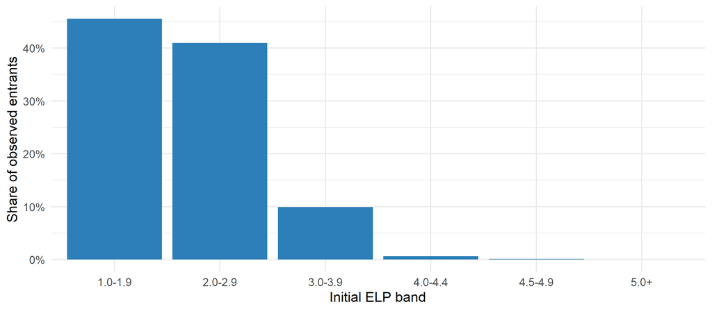

```r
plot_initial_elp(res$initial_elp)
```

```r
ft_prep2_initial_elp(res)
```

| Initial ELP | N | Share |
| --- | --- | --- |
| 1.0-1.9 | 21,866 | 45.6% |
| 2.0-2.9 | 19,671 | 41.0% |
| 3.0-3.9 | 4,756 | 9.9% |
| 4.0-4.4 | 307 | 0.6% |
| 4.5-4.9 | 63 | 0.1% |
| 5.0+ | 14 | 0.0% |
| alternate form (excluded from bands) | 173 | 0.4% |
| no annual score observed | 1,154 | 2.4% |

`$initial_elp` bands each entrant’s initial Overall Composite level using the spec’s bands (`INITIAL`, `N`, `PCT`, `IN_BANDS`). Alternate-form takers are their own row, never banded, because the alternate form reports on a different scale. Entrants with no annual score are also their own row, so shares sum to all entrants; the chart shows only the bands. `attr(res$initial_elp, "notes")` compares the result with any delivered `INITIAL_ELP`.

### Profile and monitoring

`$profile` is a named list with one table (`VALUE`, `N`, `PCT`, `SUPPRESSED`) per profile column the roster carries, plus `TIME_IN_STATUS`. Each covers current ELs in the latest year, unweighted. A long value list keeps its 12 most common values and folds the rest into “(all other values)”. Values stay in the delivery’s own codes. The stage report shows every table; here are three:

```r
ft_prep2_profile(list(profile = res$profile[c("SERVICE_MODEL", "IEP",
                                              "TIME_IN_STATUS")]))
```

| Variable | Value | N | Share |
| --- | --- | --- | --- |
| SERVICE_MODEL | esl_pullout | 7,548 | 30.3% |
| SERVICE_MODEL | esl_pushin | 5,442 | 21.8% |
| SERVICE_MODEL | sheltered | 3,212 | 12.9% |
| SERVICE_MODEL | bilingual_trans | 2,701 | 10.8% |
| SERVICE_MODEL | bilingual_tw | 2,284 | 9.2% |
| SERVICE_MODEL | newcomer_program | 2,273 | 9.1% |
| SERVICE_MODEL | refused_services | 1,478 | 5.9% |
| IEP | N | 20,392 | 81.8% |
| IEP | Y | 4,546 | 18.2% |
| TIME_IN_STATUS | 1 year (new) | 4,364 | 17.5% |
| TIME_IN_STATUS | 2-5 years | 14,329 | 57.5% |
| TIME_IN_STATUS | 6+ years (long-term) | 6,245 | 25.0% |

`$monitoring` counts former ELs by monitoring year and school year, a proposed view (`ft_prep2_monitoring(res)`).

### The analytic sample memo

`$analytic_sample_memo` summarizes the slots in short statements. The stage report prints it in its “Decide” section. It reports what the numbers say, never what to do about them.

```r
cat(paste0("- ", res$analytic_sample_memo), sep = "\n")
```

- **Panel.** 11 years (2015–2025).
- **Size.** 24,938 current ELs in 2025 (11-year average 22,339).
- **Grade concentration (2025).** Grades 2, 3, 1 hold 34.2% of current ELs; K-5 holds 61.3%.
- **Districts (2025).** 6 of 12 districts hold two-thirds of current ELs; 0 districts serve fewer than 100.
- **Entry.** 62.0% of observed entrants enter in K or grade 1. K-start cohorts that cover the full exit window: 2015 (n = 2,373, 11 years observed); 2016 (n = 2,360, 10 years observed); 2017 (n = 2,411, 9 years observed); 2018 (n = 2,403, 8 years observed); 2019 (n = 2,374, 7 years observed) (plus 6 shorter cohorts, censored at the window’s edge).
- **Time in status (2025).** 17.5% of current ELs are in their first year; 25.0% have 6+ years (long-term); entry is unknown for 0.0% (already EL when the panel opened, no entry field delivered).
- **Alternate-form ELP.** 0.7% of current ELs in 2025 take the alternate form (reported as a group, never banded).

## How to read it

Read Prep 2 for two things.

**1. The shape of the EL population in its own right.** An exit policy applies to every EL but does not land evenly: grades and districts where ELs concentrate feel a threshold change most. In this run, K–5 holds 61.3% of current ELs in 2025, and 6 of 12 districts hold two-thirds of them.

**2. The compositional facts that shape the later stages.**

- **Mostly K/1 entry.** Here 62.0% of observed entrants enter in K or grade 1 (54.7% in K alone). A kindergarten cohort speaks for the largest group of entrants and only for them: Check 1’s K-start results describe that one entry cohort, not students who enter later and not the state’s overall exit rate.
- **Attrition by grade.** Read the latest year down the grade table. Grade 2 holds the most current ELs (11.8%) and grade 12 holds 3.8%. As students move up, some exit and some leave the data, while later entrants join. Upper-grade ELs are a selected group: those who have not exited yet, plus later arrivals. This snapshot does not measure attrition; Check 1 does, for one cohort.
- **Concentrated long-term ELs.** Long-term ELs first appear in grade 5 and make up 46.1% to 68.1% of each grade from there up.

These patterns justify reading some grades’ evidence more cautiously later, and analyzing newly arrived and long-term ELs as separate groups.

**Resist the urge to average**

A single statewide number, or an “average district,” hides the profiles that matter. Prep 2 reports distributions and shares by grade, district and time in status so the concentration stays visible. Keep it that way in the stages that follow.

## Pitfalls

- **Count students from the roster only**, never from the ELP base table (WIDA-style data have eight rows per student-year) or the academic table (one row per subject). Your own side analyses should do the same.
- **Weight never-EL rows.** If they are a sample, deliver `SAMPLE_WEIGHT`; without it each row counts once and the EL share is wrong. No unweighted never-EL total belongs in any output.
- **Use the spec’s district bands, not a delivered size column.** The simulated roster’s `DISTRICT_SIZE_BAND` measures something else, and Prep 2 ignores it on purpose. Bins include their lower edge, so a district with exactly 100 ELs falls in the second band; make sure labels match breaks.
- **Do not lower `min_cell` or pool grades to make a cell appear.**
- **No mean time in status.** Report distributions and the long-term range, and treat a wide range as a range, not a midpoint.
- **Check the entry notes.** A start-date convention that differs from `entry_date_rule` puts delivered entry years off by one, which moves the entry, time-in-status and initial-ELP views. (`$entry_cohorts` and Check 1’s cohorts date entry from status changes in the panel, so they are unaffected.)
- **Two kindergarten rules, on purpose.** With no entry field to date them, students in K in the panel’s first year count as K entrants in the entry views. Without a `LEFT_TRUNCATED` flag (marking students whose entry predates the data), the shared cohort function behind `$entry_cohorts` and Check 1 drops every first-year entrant, so the entry views can count K entrants that `$entry_cohorts` leaves out.
- **Keep the excluded groups visible.** Prep 2 never bands alternate-form takers; they are always their own group. “Former” means former within the monitoring window when formers leave the data.
- **Simulated numbers are not findings.** The simulation has few, large districts and fully dated entry, so it cannot show how small districts or missing entry fields behave.

## Decide before moving on

Answer these with the memo and tables in hand:

- **Which cohorts and subgroups are large and stable enough to analyze?** Is there a clean kindergarten cohort for Check 1: observed at entry, unaffected by an enrollment anomaly, well above the suppression floor?
- **Which grades, districts or subgroups would a policy change affect most?** They deserve closer attention in every later stage.
- **Where would one pooled “all ELs” analysis hide more than it shows?** Most often: newly arrived vs. long-term ELs, and the grades where long-term ELs concentrate.

Check 1 considers the kindergarten cohorts that cover the full exit window and analyzes the one with the longest observed follow-up. A cohort below `min_cell` is never selected. Preview its choice now:

```r
compute_cohorts(bundle, spec)[c("COHORT_LABEL", "N_ENTRY",
                                "FOLLOWUP_YEARS", "SELECTED")]
```

```
# A tibble: 5 × 4
  COHORT_LABEL N_ENTRY FOLLOWUP_YEARS SELECTED
  <chr>          <int>          <int> <lgl>
1 K-2015          2373             11 TRUE
2 K-2016          2360             10 FALSE
3 K-2017          2411              9 FALSE
4 K-2018          2403              8 FALSE
5 K-2019          2374              7 FALSE
```

Carry forward:

- **The cohort**, and whether its years include a disruption. The coverage table shows whether it hit enrollment or only testing.
- **The grades with a heavy long-term share.** Check 3’s results there may reflect who is still an EL, not where the threshold sits.
- **Where ELs concentrate**, for framing any recommendation.
- **The excluded groups**: alternate-form takers and any unknown-entry students. Neither appears in the banded views.

## Additional checks for multi-criterion exit rules

This check applies only when the exit rule combines criteria: Types 2–6 in the package’s typology (a Type 2 rule, for example, adds a domain-score floor to the overall score). Prep 2 then builds a **criteria crosswalk**: pass/fail patterns on each criterion near the overall cut; **blocked groups**, student-years near the cut that fail exactly one criterion; and the **contested zone**, the range of Overall Composite levels where the criteria disagree (some pass, some fail). Check 2 adds the blocked groups as comparison columns and Check 3 models the contested zone; both recompute them with `compute_criteria_crosswalk()`.

To tell whether the check applies, look at the declared Types and the terms of each exit pathway:

```r
spec_exit_types(spec)
```

```
[1] 1
```

```r
spec_has_type(spec, 2:6)
```

```
[1] FALSE
```

```r
length(spec$policy$exit$pathways[[1]]$terms)
```

```
[1] 1
```

The simulated spec is Type 1 with one term, so `$criteria_crosswalk`, `$contested_zone` and `$blocked_groups` are `NULL`. The gate needs a declared Type of 2–6 *and* a pathway with two or more ELP terms. A Type 5 spec whose pathways have one term each opens the gate but still gets `NULL`, with the reason in `$meta$notes$crosswalk`.

To show the output, the chunk below adds a **hypothetical** second criterion to the simulated rule, a Reading level of at least 4.0 (waived when the domain is absent). The package’s tests use the same variant; it is not the simulated state’s rule. With a Type 2–6 spec, `run_prep2()` fills these slots itself. Here the crosswalk is computed directly to avoid rerunning the stage.

```r
spec_t2 <- spec
spec_t2$policy$exit$pathways[[1]]$terms[[2]] <- list(
  component = "reading", measure = "level", op = ">=", value = 4.0,
  exempt_if_absent = TRUE)
spec_t2$policy$exit$pathways[[1]]$rule <-
  "Overall composite level >= 4.5 and reading level >= 4.0"
spec_t2$policy$exit$types <- 2L
validate_el_spec(spec_t2)

cw <- compute_criteria_crosswalk(bundle, spec_t2)
res_t2 <- res
res_t2$criteria_crosswalk <- cw$crosswalk          # aggregate tables only;
res_t2$contested_zone     <- cw$contested_zone     # cw$blocked_groups is per student
```

```r
cat(prep2_crosswalk_note(res_t2), "\n\n")
```

Criteria (overall_composite pathway): `OVERALL_LEVEL` (overall level >= 4.5); `READING_LEVEL` (reading level >= 4, exempt if absent). Combination assumed conjunctive, all must pass [PROPOSED - CONFIRM]. Window: Overall Composite level within ±0.5 of the cut 4.5; 59,757 of 231,954 current annual student-years.

```r
cat(prep2_contested_note(res_t2), "\n")
```

**Contested zone.** Across all 231,954 current annual student-years, the criteria disagree for 34,983 (15.1%). Overall Composite level of disagreeing student-years: 2.7–5.1 (central 90%: 3.6–4.4). This range carries forward to Data Check 3.

```r
ft_prep2_crosswalk_pattern(res_t2)
```

| OVERALL_LEVEL | READING_LEVEL | Student-years | Share |
| --- | --- | --- | --- |
| fail | fail | 10,498 | 17.6% |
| fail | pass | 22,168 | 37.1% |
| pass | fail | 860 | 1.4% |
| pass | pass | 26,231 | 43.9% |

```r
ft_prep2_crosswalk_blocked(res_t2)
```

| Group | Student-years | Share |
| --- | --- | --- |
| blocked by OVERALL_LEVEL only | 22,168 | 37.1% |
| blocked by READING_LEVEL only | 860 | 1.4% |
| blocked by more than one criterion | 10,498 | 17.6% |
| passes every criterion | 26,231 | 43.9% |

The window around the cut is `spec$policy$exit$zone_half_width` (0.5 levels by default). `ft_prep2_crosswalk_by_level(res_t2)` shows where the criteria disagree in 0.1-level bins across twice that window.

The contested zone is where to ask whether the second criterion does independent work or restates the overall score; Check 3 asks it there. Only the “blocked by `READING_LEVEL` only” group is held back by the second criterion alone. A wide zone, or a large group blocked by one domain alone, is a question for Checks 2 and 3, not a finding. Three limits: the crosswalk uses the first pathway with two or more ELP terms; it assumes all criteria must pass; and it reads only ELP terms. A Type 3 rule’s non-ELP criterion (an academic score, say) is never evaluated, so a rule with one ELP term plus an academic term gets no crosswalk at all.

## Render the stage report

The stage report holds the figures and tables shown above (the crosswalk tables only for a Type 2–6 rule), plus the walkthrough text and the Decide box. The example report on the simulated data is on the project site.

```r
# Simulated data: Word and HTML, written to reports/
render_step("prep2")
```

On its own, the report computes results only from the simulated data. For your state, compute the results, save them outside the folder you share, and render from the saved file. Then scan the output against your own roster:

```r
res <- run_prep2(bundle, spec)
dir.create("results", showWarnings = FALSE)
saveRDS(res, "results/prep2_results.rds")

files <- render_step("prep2",
                     spec_file        = normalizePath("specs/XX_EL_Spec.R"),
                     results_file     = "results/prep2_results.rds",
                     check_disclosure = FALSE)
check_output_disclosure(files, bundle)   # stops if any STUDENT_ID appears
```

`check_disclosure = FALSE` turns off the built-in scan, which knows only the simulated students; `check_output_disclosure()` replaces it.

Guide home | Previous: Prep 1: Policy documentation | Next: Prep 3: Program implementation